# Boston with R Notebook

KNN & decision tree

Peter Morris

October 22, 2021

# 1 Boston - Data set

Library: Mass

Housing Values in Suburbs of Boston

The Boston data frame has 506 rows and 14 columns.

`crim` per capita crime rate by town. `crim` per capita crime rate by town. `zn` proportion of residential land zoned for lots over 25,000 sq.ft. `indus` proportion of non-retail business acres per town. `chas` Charles River dummy variable (= 1 if tract bounds river; 0 otherwise). `nox` nitrogen oxides concentration (parts per 10 million). `rm` average number of rooms per dwelling. `age` proportion of owner-occupied units built prior to 1940. `dis` weighted mean of distances to five Boston employment centres. `rad` index of accessibility to radial highways. `tax` full-value property-tax rate per $10,000. `ptratio` pupil-teacher ratio by town. `black` 1000(Bk - 0.63)^2 where Bk is the proportion of blacks by town. `lstat` lower status of the population (percent). `medv` median value of owner-occupied homes in $1000s.

# 2 Exploratory Analysis

```r
library(MASS)
names(Boston)
```

```
 [1] "crim"    "zn"      "indus"   "chas"    "nox"     "rm"      "age"     "dis"     "rad"     "tax"     "ptratio" "black"
[13] "lstat"   "medv"
```

```r
mod <- c("MLR - Multiple linear regression","Decision Tree","KNN - k-nearest neighbors algorithm")
quadloss <- c(0,0,0)
quadratic.loss <- data.frame(mod,quadloss)
```

```r
head(Boston)
```

|  | crim | zn | indus | chas | nox | rm | age | dis | rad | tax | ptratio | black | lstat | medv |
| --- | --- | --- | --- | --- | --- | --- | --- | --- | --- | --- | --- | --- | --- | --- |
| 1 | 0.00632 | 18 | 2.31 | 0 | 0.538 | 6.575 | 65.2 | 4.0900 | 1 | 296 | 15.3 | 396.90 | 4.98 | 24.0 |
| 2 | 0.02731 | 0 | 7.07 | 0 | 0.469 | 6.421 | 78.9 | 4.9671 | 2 | 242 | 17.8 | 396.90 | 9.14 | 21.6 |
| 3 | 0.02729 | 0 | 7.07 | 0 | 0.469 | 7.185 | 61.1 | 4.9671 | 2 | 242 | 17.8 | 392.83 | 4.03 | 34.7 |
| 4 | 0.03237 | 0 | 2.18 | 0 | 0.458 | 6.998 | 45.8 | 6.0622 | 3 | 222 | 18.7 | 394.63 | 2.94 | 33.4 |
| 5 | 0.06905 | 0 | 2.18 | 0 | 0.458 | 7.147 | 54.2 | 6.0622 | 3 | 222 | 18.7 | 396.90 | 5.33 | 36.2 |
| 6 | 0.02985 | 0 | 2.18 | 0 | 0.458 | 6.430 | 58.7 | 6.0622 | 3 | 222 | 18.7 | 394.12 | 5.21 | 28.7 |

```r
tail(Boston)
```

|  | crim | zn | indus | chas | nox | rm | age | dis | rad | tax | ptratio | black | lstat | medv |
| --- | --- | --- | --- | --- | --- | --- | --- | --- | --- | --- | --- | --- | --- | --- |
| 501 | 0.22438 | 0 | 9.69 | 0 | 0.585 | 6.027 | 79.7 | 2.4982 | 6 | 391 | 19.2 | 396.90 | 14.33 | 16.8 |
| 502 | 0.06263 | 0 | 11.93 | 0 | 0.573 | 6.593 | 69.1 | 2.4786 | 1 | 273 | 21.0 | 391.99 | 9.67 | 22.4 |
| 503 | 0.04527 | 0 | 11.93 | 0 | 0.573 | 6.120 | 76.7 | 2.2875 | 1 | 273 | 21.0 | 396.90 | 9.08 | 20.6 |
| 504 | 0.06076 | 0 | 11.93 | 0 | 0.573 | 6.976 | 91.0 | 2.1675 | 1 | 273 | 21.0 | 396.90 | 5.64 | 23.9 |
| 505 | 0.10959 | 0 | 11.93 | 0 | 0.573 | 6.794 | 89.3 | 2.3889 | 1 | 273 | 21.0 | 393.45 | 6.48 | 22.0 |
| 506 | 0.04741 | 0 | 11.93 | 0 | 0.573 | 6.030 | 80.8 | 2.5050 | 1 | 273 | 21.0 | 396.90 | 7.88 | 11.9 |

```r
dim(Boston)
```

```
[1] 506  14
```

```r
summary(Boston)
```

```
      crim                zn             indus            chas              nox               rm             age
 Min.   : 0.00632   Min.   :  0.00   Min.   : 0.46   Min.   :0.00000   Min.   :0.3850   Min.   :3.561   Min.   :  2.90
 1st Qu.: 0.08205   1st Qu.:  0.00   1st Qu.: 5.19   1st Qu.:0.00000   1st Qu.:0.4490   1st Qu.:5.886   1st Qu.: 45.02
 Median : 0.25651   Median :  0.00   Median : 9.69   Median :0.00000   Median :0.5380   Median :6.208   Median : 77.50
 Mean   : 3.61352   Mean   : 11.36   Mean   :11.14   Mean   :0.06917   Mean   :0.5547   Mean   :6.285   Mean   : 68.57
 3rd Qu.: 3.67708   3rd Qu.: 12.50   3rd Qu.:18.10   3rd Qu.:0.00000   3rd Qu.:0.6240   3rd Qu.:6.623   3rd Qu.: 94.08
 Max.   :88.97620   Max.   :100.00   Max.   :27.74   Max.   :1.00000   Max.   :0.8710   Max.   :8.780   Max.   :100.00
      dis              rad              tax           ptratio          black            lstat            medv
 Min.   : 1.130   Min.   : 1.000   Min.   :187.0   Min.   :12.60   Min.   :  0.32   Min.   : 1.73   Min.   : 5.00
 1st Qu.: 2.100   1st Qu.: 4.000   1st Qu.:279.0   1st Qu.:17.40   1st Qu.:375.38   1st Qu.: 6.95   1st Qu.:17.02
 Median : 3.207   Median : 5.000   Median :330.0   Median :19.05   Median :391.44   Median :11.36   Median :21.20
 Mean   : 3.795   Mean   : 9.549   Mean   :408.2   Mean   :18.46   Mean   :356.67   Mean   :12.65   Mean   :22.53
 3rd Qu.: 5.188   3rd Qu.:24.000   3rd Qu.:666.0   3rd Qu.:20.20   3rd Qu.:396.23   3rd Qu.:16.95   3rd Qu.:25.00
 Max.   :12.127   Max.   :24.000   Max.   :711.0   Max.   :22.00   Max.   :396.90   Max.   :37.97   Max.   :50.00
```

```r
cor(Boston)
```

```
               crim          zn       indus         chas         nox          rm         age         dis          rad
crim     1.00000000 -0.20046922  0.40658341 -0.055891582  0.42097171 -0.21924670  0.35273425 -0.37967009  0.625505145
zn      -0.20046922  1.00000000 -0.53382819 -0.042696719 -0.51660371  0.31199059 -0.56953734  0.66440822 -0.311947826
indus    0.40658341 -0.53382819  1.00000000  0.062938027  0.76365145 -0.39167585  0.64477851 -0.70802699  0.595129275
chas    -0.05589158 -0.04269672  0.06293803  1.000000000  0.09120281  0.09125123  0.08651777 -0.09917578 -0.007368241
nox      0.42097171 -0.51660371  0.76365145  0.091202807  1.00000000 -0.30218819  0.73147010 -0.76923011  0.611440563
rm      -0.21924670  0.31199059 -0.39167585  0.091251225 -0.30218819  1.00000000 -0.24026493  0.20524621 -0.209846668
age      0.35273425 -0.56953734  0.64477851  0.086517774  0.73147010 -0.24026493  1.00000000 -0.74788054  0.456022452
dis     -0.37967009  0.66440822 -0.70802699 -0.099175780 -0.76923011  0.20524621 -0.74788054  1.00000000 -0.494587930
rad      0.62550515 -0.31194783  0.59512927 -0.007368241  0.61144056 -0.20984667  0.45602245 -0.49458793  1.000000000
tax      0.58276431 -0.31456332  0.72076018 -0.035586518  0.66802320 -0.29204783  0.50645559 -0.53443158  0.910228189
ptratio  0.28994558 -0.39167855  0.38324756 -0.121515174  0.18893268 -0.35550149  0.26151501 -0.23247054  0.464741179
black   -0.38506394  0.17552032 -0.35697654  0.048788485 -0.38005064  0.12806864 -0.27353398  0.29151167 -0.444412816
lstat    0.45562148 -0.41299457  0.60379972 -0.053929298  0.59087892 -0.61380827  0.60233853 -0.49699583  0.488676335
medv    -0.38830461  0.36044534 -0.48372516  0.175260177 -0.42732077  0.69535995 -0.37695457  0.24992873 -0.381626231
                tax    ptratio       black      lstat       medv
crim     0.58276431  0.2899456 -0.38506394  0.4556215 -0.3883046
zn      -0.31456332 -0.3916785  0.17552032 -0.4129946  0.3604453
indus    0.72076018  0.3832476 -0.35697654  0.6037997 -0.4837252
chas    -0.03558652 -0.1215152  0.04878848 -0.0539293  0.1752602
nox      0.66802320  0.1889327 -0.38005064  0.5908789 -0.4273208
rm      -0.29204783 -0.3555015  0.12806864 -0.6138083  0.6953599
age      0.50645559  0.2615150 -0.27353398  0.6023385 -0.3769546
dis     -0.53443158 -0.2324705  0.29151167 -0.4969958  0.2499287
rad      0.91022819  0.4647412 -0.44441282  0.4886763 -0.3816262
tax      1.00000000  0.4608530 -0.44180801  0.5439934 -0.4685359
ptratio  0.46085304  1.0000000 -0.17738330  0.3740443 -0.5077867
black   -0.44180801 -0.1773833  1.00000000 -0.3660869  0.3334608
lstat    0.54399341  0.3740443 -0.36608690  1.0000000 -0.7376627
medv    -0.46853593 -0.5077867  0.33346082 -0.7376627  1.0000000
```

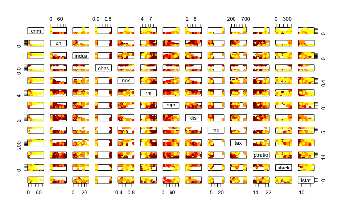

```r
dircolor=rep("yellow", nrow(Boston))
dircolor[Boston$medv>=17.02]="orange"
dircolor[Boston$medv>=22.53]="red"
dircolor[Boston$medv>=25]="darkred"

pairs(Boston[,-14], col=dircolor, pch=19)
```

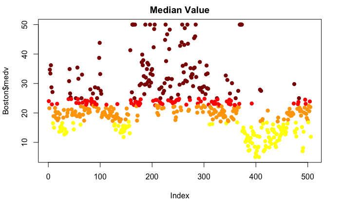

```r
plot(Boston$medv, col=dircolor, pch=19)
title("Median Value")
```

# 3 Data partition

## 3.1 Trainning data set

```r
sample_number=sample(1:nrow(Boston), size=0.7*nrow(Boston))
data.train=Boston[sample_number,]
dim(data.train)
```

```
[1] 354  14
```

## 3.2 Testing data set

```r
data.test=Boston[-sample_number,]
dim(data.test)
```

```
[1] 152  14
```

# 4 MLR - Multiple linear regression

```r
mod.LM=lm(medv~., data=data.train)
predit.LM=predict(mod.LM, data.test)
quadratic.loss[1,2]=mean((data.test[,14]-predit.LM)^2)
quadratic.loss[1,]
```

|  | mod | quadloss |
| --- | --- | --- |
| 1 | MLR - Multiple linear regression | 20.16895 |

# 5 Decision Tree

## 5.1 Model fitting

Tree rules:

```r
library(rpart)
library(rpart.plot)
treefit=rpart(medv~., method="anova", data=data.train)
rpart.rules(treefit)
```

|  | medv |  |  |  |  |  |  |  |  |  |  |  |  |  |  |  |  |  |  |  |  |
| --- | --- | --- | --- | --- | --- | --- | --- | --- | --- | --- | --- | --- | --- | --- | --- | --- | --- | --- | --- | --- | --- |
| 8 | 12 | when | rm | < | 6.9 |  |  | & | lstat | >= |  |  | 14.4 |  |  |  |  | & | crim | >= | 7.2 |
| 9 | 17 | when | rm | < | 6.9 |  |  | & | lstat | >= |  |  | 14.4 |  |  |  |  | & | crim | < | 7.2 |
| 10 | 21 | when | rm | < | 6.9 |  |  | & | lstat | is | 9.8 | to | 14.4 |  |  |  |  |  |  |  |  |
| 44 | 23 | when | rm | < | 6.5 |  |  | & | lstat | < | 9.8 |  |  | & | dis | >= | 2.1 |  |  |  |  |
| 45 | 27 | when | rm | is | 6.5 | to | 6.9 | & | lstat | < | 9.8 |  |  | & | dis | >= | 2.1 |  |  |  |  |
| 12 | 28 | when | rm | is | 6.9 | to | 7.4 | & | lstat | >= |  |  | 7.0 |  |  |  |  |  |  |  |  |
| 13 | 34 | when | rm | is | 6.9 | to | 7.4 | & | lstat | < | 7.0 |  |  |  |  |  |  |  |  |  |  |
| 23 | 37 | when | rm | < | 6.9 |  |  | & | lstat | < | 9.8 |  |  | & | dis | < | 2.1 |  |  |  |  |
| 7 | 45 | when | rm | >= |  |  | 7.4 |  |  |  |  |  |  |  |  |  |  |  |  |  |  |

Plotting the tree

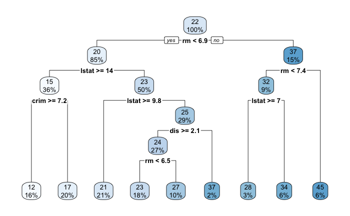

```r
rpart.plot(treefit)
```

```r
treefit$cptable
```

```
          CP nsplit rel error    xerror       xstd
1 0.46185232      0 1.0000000 1.0050234 0.09964610
2 0.18219151      1 0.5381477 0.6300050 0.07174478
3 0.07059300      2 0.3559562 0.4342900 0.05935665
4 0.03173181      3 0.2853632 0.3413871 0.05189467
5 0.02461154      5 0.2218996 0.3235482 0.04852997
6 0.01333554      6 0.1972880 0.2921277 0.04312339
7 0.01059293      7 0.1839525 0.2587940 0.03169919
8 0.01000000      8 0.1733596 0.2575866 0.03167723
```

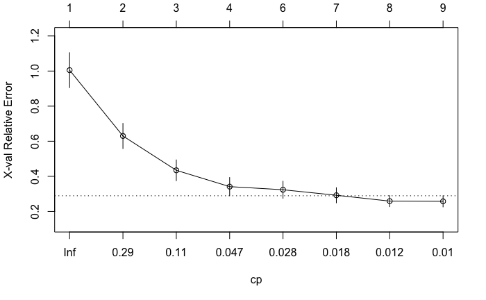

```r
plotcp(treefit)
```

## 5.2 Prune

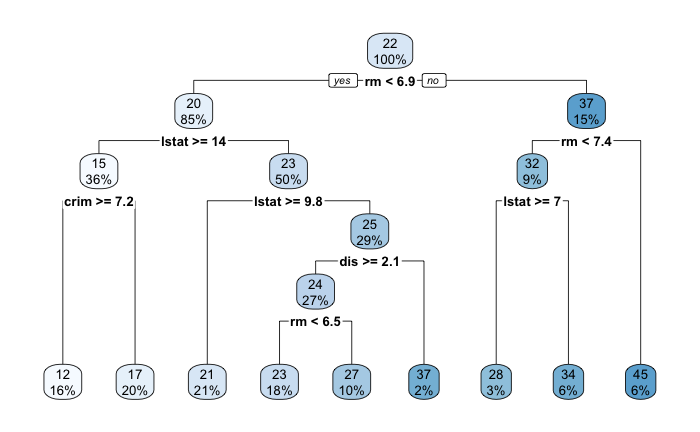

```r
best_cp <- treefit$cptable[which.min(treefit$cptable[, "xerror"]), "CP"]
prunefit <- rpart::prune(treefit, cp = best_cp)
rpart.plot(prunefit)
```

## 5.3 Evaluation of prediction model

```r
pred=predict(prunefit, data.test)
quadratic.loss[2,2]=mean((data.test[,14]-pred)^2)
quadratic.loss[2,]
```

|  | mod | quadloss |
| --- | --- | --- |
| 2 | Decision Tree | 20.16838 |

# 6 KNN - k-nearest neighbors algorithm

```r
library(FNN)
mod.KNN=knn.reg(train=data.train[,-14], test=data.test[,-14], y=data.train[,14], k=5)
```

## 6.1 Evaluation of prediction model

```r
quadratic.loss[3,2]=mean((data.test[,14]-mod.KNN$pred)^2)
quadratic.loss[3,]
```

|  | mod | quadloss |
| --- | --- | --- |
| 3 | KNN - k-nearest neighbors algorithm | 40.33438 |

# 7 Comparing quadratic loss

```r
quadratic.loss
```

| mod | quadloss |
| --- | --- |
| MLR - Multiple linear regression | 20.16895 |
| Decision Tree | 20.16838 |
| KNN - k-nearest neighbors algorithm | 40.33438 |